# Ford GoBike System Data

## by Abdullahi Adedayo

## Investigation Overview

> Checking the distribution of durations in an appropriate measurement Viewing the number of rides per day and per month Visualizing the ride duration per day and for each user type.

## Dataset Overview

> This dataset provides information about the bikes trips, users, trip durations ,start date and time, end station and bikes IDs.

## (Trip Duration in Minute)

> This plot was made using logarithmic scaleon the x axis. The duration values seem to be normally distributed. It is clear that durations mostly are between 5 to 15 minutes as most of the points lie between those boundaries. values around 500 are also present but it seems impossible to ride for upto half a day therefore these values are mostly outliers

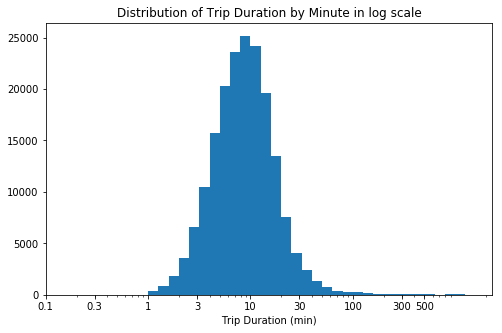

## (Day count trip)

> This plot shows that most trip took place during midweek due to the fact that most Thursday and Tuesday have the highest trips while their are minimum number of trips during weekends as Saturday and Sunday recorded fewest trips

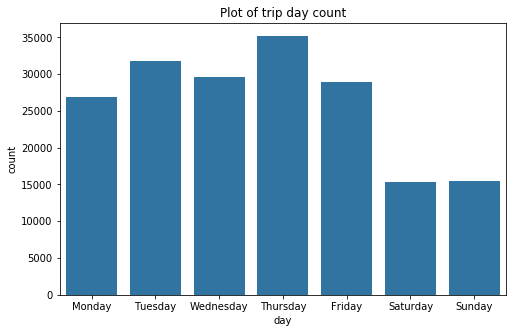

## (Types of bike users)

> As shown below, the subscribers have the higher percentage compare to the Customer users

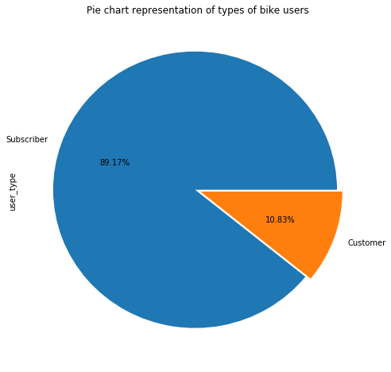